Andrea Botta - BSE Summer School 2025 - Advanced Portfolio Management

# Long-Term Portfolio Strategy for Private Wealth Client

## 01. Introduction

This report outlines some long-term investment strategies for a private client based in the United States with available capital of $100 million. The portfolios are constructed using optimization algorithms under specific constraints and aim to achieve an optimal balance between expected return and risk by leveraging diversification across multiple asset classes through Exchange Traded Funds (ETFs).

Specifically, the report develops portfolios on two main optimizations: mean-variance optimization and VaR-Constrained optimization. Initially, historical return data (monthly returns) is used, calculates the efficient frontier, and identifies the optimal Mean-Variance and VaR-constrained portfolios. Then, noting the overweight of some assets in portfolios with historical data, new optimal portfolio allocations are computed through Cross Validation and Ridge Regression.

The analysis also analyzes the estimation risk and makes considerations about the different investment strategies that emerge from the optimizations.

### Client Profile

The client has the following characteristics:

- Type of investor: Private Investor
- Geographical location: United States
- Initial Net Worth allocated for investments: USD 100 million
- Strategy: Long-term - balancing risk and return

### Portfolio Characteristics & Constraints

Key constraints include:

- Minimum of 20% allocation in bonds or money market instruments;
- No short sales allowed;
- Use of ETFs with at least 10 years of historical data;
- Investment across various asset classes: Bonds, Equities, Commodities, Precious Metals, Real Estate, and Money Market;
- A Value at Risk (VaR) limit: 1-month VaR at 99% confidence level must not exceed 3%;
- ETFs should be representative of their asset class, not selected for outperformance;
- Uses a limited number of ETFs to ensure clarity, cost-efficiency, and ease of communication with the client.

## 02. ETFs Selection and Diversification Analysis

### ETFs Selection

To construct the portfolio, it's important to choose ETFs to represent the major asset classes. The selection was guided by:

1. **Representativeness**: ETFs were chosen to represent their asset class, not to “beat the market.”
2. **Sufficient History**: Only ETFs with at least 10 years of historical data were considered. This ensures the reliability of return and risk estimates, which are based on monthly data.
3. **Liquidity and Scale**: Preference was given to large, highly liquid ETFs with high trading volumes and large assets under management. These ETFs are widely used and provide cost-effective access.

| Ticker | Asset Class | ETF Name | Inception Year | Rationale |
| --- | --- | --- | --- | --- |
| **AGG** | Bonds | iShares Core U.S. Aggregate Bond ETF | 2003 | Broad exposure to U.S. investment-grade bonds. Acts as a stabilizer with relatively low volatility. |
| **SPY** | Equities (U.S.) | SPDR S&P 500 ETF Trust | 1993 | Tracks the U.S. large-cap equity market. Most liquid ETF globally, widely recognized. |
| **DBC** | Commodities | Invesco DB Commodity Index ETF | 2006 | Provides diversified exposure to major commodities (energy, agriculture, metals). Useful in inflationary regimes. |
| **GLD** | Precious Metals | SPDR Gold Shares | 2004 | Physically backed gold ETF. Acts as a safe-haven asset and potential hedge against macro risks. |
| **VNQ** | Real Estate | Vanguard Real Estate ETF | 2004 | Provides access to the U.S. RE market. Adds diversification and potential income. |
| **SHV** | Money Market | iShares Short Treasury Bond ETF | 2007 | Ultra-short-term U.S. Treasuries. Very low risk, enhances liquidity and capital preservation. |

### Descriptive Statistics and Diversification Analysis

The ETFs shown above represent the benchmark for each asset class shown. To understand what contribution each asset class could make to the portfolio we look at the following statistics based on the last 18 years of data:

| Asset Class | Expected Return (%) | Volatility (%) | Sharpe Ratio | Skewness | Kurtosis |
| --- | --- | --- | --- | --- | --- |
| Equities (SPY) | 0.95 | 4.58 | 0.18 | -0.58 | 3.82 |
| Gold (GLD) | 0.74 | 4.89 | 0.13 | -0.00 | 3.24 |
| Bonds (AGG) | 0.24 | 1.37 | 0.10 | 0.32 | 5.83 |
| Real Estate (VNQ) | 0.74 | 6.54 | 0.10 | -0.61 | 8.21 |
| Money Market (SHV) | 0.10 | 0.16 | 0.00 | 1.32 | 3.79 |
| Commodities (DBC) | 0.05 | 5.44 | -0.01 | -0.66 | 5.00 |

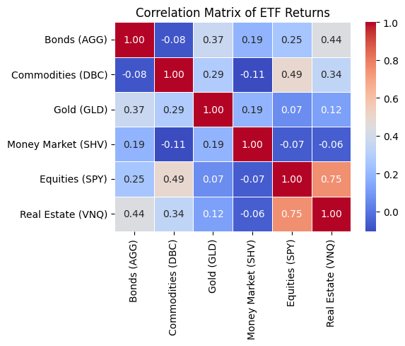

```python
# mean-variance Optimization
from scipy.stats import kurtosis, skew
import yfinance as yf
import pandas as pd
import numpy as np
import matplotlib.pyplot as plt
import seaborn as sns

tickers = ["AGG", "SPY", "DBC", "GLD", "VNQ", "SHV"]

# Download 10 years of monthly data
data = yf.download(tickers, start="2007-12-01", end="2025-06-30", auto_adjust=True, progress=False)["Close"]
names = {
    "SPY": "Equities (SPY)",
    "AGG": "Bonds (AGG)",
    "DBC": "Commodities (DBC)",
    "GLD": "Gold (GLD)",
    "VNQ": "Real Estate (VNQ)",
    "SHV": "Money Market (SHV)"
}

monthly_prices = data.resample('ME').last()

# Store the columns with dates and industry names (useful later)
dates = monthly_prices.index

# Rename columns to descriptive names
monthly_prices.columns = [names[ticker] for ticker in monthly_prices.columns]

# Compute returns
returns = monthly_prices.pct_change().dropna()

# Descriptive Statistics
rf = returns["Money Market (SHV)"]  # Use the monthly SHV returns as the risk-free rate series
sharpe_ratio = (returns.mean() - rf.mean()) / returns.std()
summary_stats = pd.DataFrame({
    "Exp Ret (%)": returns.mean() * 100,
    "Volatilty (%)": returns.std() * 100,
    "Sharpe Ratio": sharpe_ratio,
    'Skew': returns.apply(skew, nan_policy='omit'),
    'Kurt': returns.apply(kurtosis, fisher=False, nan_policy='omit')  # Fisher=False gives normal kurtosis (3 for normal)
}).sort_values("Sharpe Ratio", ascending=False)

# print(summary_stats.round(2))

# Diversification Analysis - Correlation Matrix
plt.figure(figsize=(6, 5))
sns.heatmap(returns.corr(), annot=True, cmap="coolwarm", fmt=".2f", linewidths=0.5)
plt.title("Correlation Matrix of ETF Returns")
plt.tight_layout()
plt.show()
```

The selected ETFs have unique risk/return profiles and complementary behaviors that, together, increase the portfolio's diversification potential. The comparison of expected returns, volatility, and Sharpe ratios highlights the trade-offs between growth and stability inherent in each asset class.

In short, from the characteristics of each security and the correlation matrix, we see how these asset classes allow for a well-diversified portfolio, in which uncorrelated return flows minimize the overall volatility of the portfolio and improve risk-adjusted performance. By leveraging the unique economic sensitivities of equities, bonds, real assets, and commodities, investors can build a more durable and resilient allocation across a wide range of macroeconomic environments.

## 03. Portfolio Construction & Mean-Variance Frontier Analysis

To find the efficient allocation of asset classes, we use the classic mean-variance model (Markowitz, 1952) and construct the efficient frontier with the following constraints:

- No short selling (weights ≥ 0);
- Total investment (weights that add up to 1);
- Minimum allocation of 20% in bonds or money market (AGG + SHV ≥ 0.20).

Three portfolios are calculated and analyzed:

1. Global minimum variance portfolio (GMV) – the portfolio with the lowest possible risk (variance).
2. Portfolio with maximum Sharpe ratio (tangency) – the portfolio with the optimal risk-adjusted return.
3. Equal-weighted portfolio – for benchmarking.

The efficient frontier will also be constructed, which visually demonstrates how diversification improves return per unit of risk. The optimal portfolio according to Sharpe offers a significant improvement in expected return compared to GMV with a modest increase in volatility. In fact, the combination of the global minimum variance (GMV) portfolio and the tangency portfolio (maximum Sharpe ratio) offers the client a clear view of the risk-return spectrum.

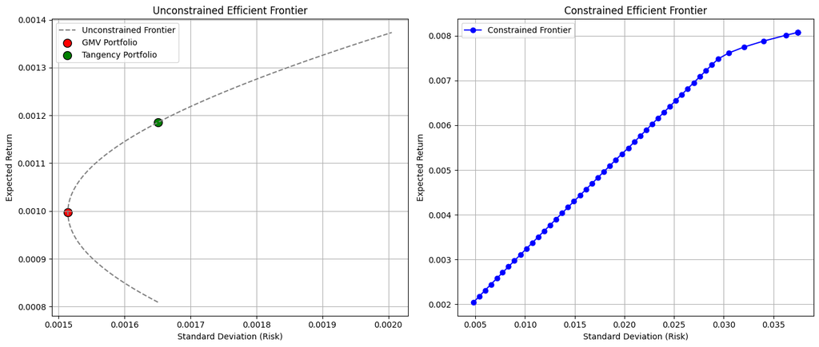

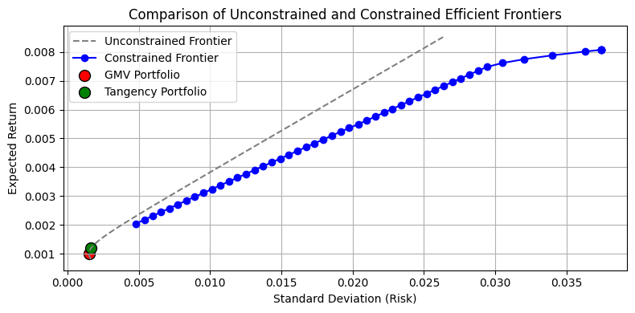

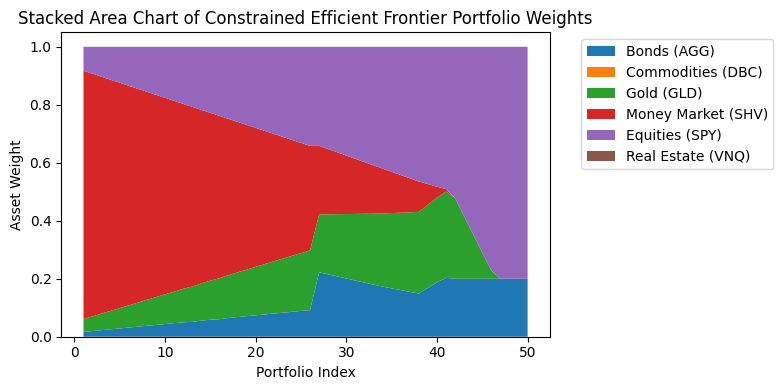

```python
# Var Constrained Optimization
from scipy.optimize import minimize

# ER, V and Corr_Matrix
ER = returns.mean()
V = returns.cov()
corr_matrix = returns.corr()

# Compute GMV and Tangency Portfolio
w1 = (np.linalg.inv(V) @ ER) / (np.sum(np.linalg.inv(V) @ ER))
w2 = (np.linalg.inv(V) @ np.ones(len(ER))) / (np.sum(np.linalg.inv(V) @ np.ones(len(ER))))

ER1 = w1 @ ER
ER2 = w2 @ ER

s1 = np.sqrt(w1 @ V @ w1)
s2 = np.sqrt(w2 @ V @ w2)

s12 = w1 @ V @ w2

# Compute the Unconstrained Frontier
p = np.linspace(-1.0, 2.0, 100)

ERp = np.zeros(len(p))
sp = np.zeros(len(p))

for j in range(len(p)):
    ERp[j] = p[j] * ER1 + (1 - p[j]) * ER2
    sp[j] = np.sqrt(p[j]**2 * s1**2 + (1 - p[j])**2 * s2**2 + 2 * p[j] * (1 - p[j]) * s12)


# Compute the Efficient Frontier with Constraints
idx_agg = list(returns.columns).index("Bonds (AGG)")
idx_shv = list(returns.columns).index("Money Market (SHV)")

min_return = ER.iloc[idx_shv] + 0.001  # Cash return
max_return = ER.max() * 0.90           # stop before the max return to avoid numerical issues


# Target Returns: da min_return a max_return
target_returns = np.linspace(min_return, max_return, 50)


efficient_frontier_weights = []
portfolio_returns = []
portfolio_std_devs = []
for target_return in target_returns:
    constraints = [
        {'type': 'eq', 'fun': lambda w: np.sum(w) - 1},                     # Full investment
        {'type': 'ineq', 'fun': lambda w: w},                               # No short-selling (w >= 0)
        {'type': 'ineq', 'fun': lambda w: w[idx_agg] + w[idx_shv] - 0.20},  # Bonds + Money Market >= 20%
        {'type': 'eq', 'fun': lambda w: np.dot(w, ER) - target_return}      # Target return
    ]

    objective = lambda w: np.dot(w.T, np.dot(V, w))
    result = minimize(objective, x0=np.ones(len(ER))/len(ER), constraints=constraints, method='SLSQP', options={'maxiter': 100000, 'ftol': 1e-9})

    efficient_frontier_weights.append(result.x)
    portfolio_returns.append(np.dot(ER, result.x))
    portfolio_std_devs.append(np.sqrt(np.dot(result.x.T, np.dot(V, result.x))))
efficient_frontier_weights = np.array(efficient_frontier_weights).T


# Create a figure with two subplots side by side
fig, axes = plt.subplots(1, 2, figsize=(14, 6))

# Plot the Unconstrained Frontier with GMV and Tangency Portfolios
axes[0].plot(sp, ERp, label='Unconstrained Frontier', linestyle='--', color='gray')
axes[0].scatter(s2, ER2, color='red', label='GMV Portfolio', s=100, edgecolor='black')
axes[0].scatter(s1, ER1, color='green', label='Tangency Portfolio', s=100, edgecolor='black')
axes[0].set_xlabel('Standard Deviation (Risk)')
axes[0].set_ylabel('Expected Return')
axes[0].set_title('Unconstrained Efficient Frontier')
axes[0].legend()
axes[0].grid(True)

# Plot the Constrained Efficient Frontier
axes[1].plot(portfolio_std_devs, portfolio_returns, label='Constrained Frontier', color='blue', marker='o')
axes[1].set_xlabel('Standard Deviation (Risk)')
axes[1].set_ylabel('Expected Return')
axes[1].set_title('Constrained Efficient Frontier')
axes[1].legend()
axes[1].grid(True)

plt.tight_layout()
plt.show()

# Make a plot to compare the Unconstrained and Constrained Efficient Frontiers
# for this case recompute the Unconstrained Frontier using p=np.linspace(-1, 20, 100)
p = np.linspace(-1.0, 40.0, 100)
ERp = np.zeros(len(p))
sp = np.zeros(len(p))
for j in range(len(p)):
    ERp[j] = p[j] * ER1 + (1 - p[j]) * ER2
    sp[j] = np.sqrt(p[j]**2 * s1**2 + (1 - p[j])**2 * s2**2 + 2 * p[j] * (1 - p[j]) * s12)
# Recompute the Efficient Frontier with Constraints
efficient_frontier_weights = []
portfolio_returns = []
portfolio_std_devs = []
for target_return in target_returns:
    constraints = [
        {'type': 'eq', 'fun': lambda w: np.sum(w) - 1},                     # Full investment
        {'type': 'ineq', 'fun': lambda w: w},                               # No short-selling (w >= 0)
        {'type': 'ineq', 'fun': lambda w: w[idx_agg] + w[idx_shv] - 0.20},  # Bonds + Money Market >= 20%
        {'type': 'eq', 'fun': lambda w: np.dot(w, ER) - target_return}      # Target return
    ]

    objective = lambda w: np.dot(w.T, np.dot(V, w))
    result = minimize(objective, x0=np.ones(len(ER))/len(ER), constraints=constraints, method='SLSQP', options={'maxiter': 100000, 'ftol': 1e-9})

    efficient_frontier_weights.append(result.x)
    portfolio_returns.append(np.dot(ER, result.x))
    portfolio_std_devs.append(np.sqrt(np.dot(result.x.T, np.dot(V, result.x))))
efficient_frontier_weights = np.array(efficient_frontier_weights).T

# Plot the comparison of Unconstrained and Constrained Efficient Frontiers
plt.figure(figsize=(8, 4))
plt.plot(sp, ERp, label='Unconstrained Frontier', linestyle='--', color='gray')
plt.plot(portfolio_std_devs, portfolio_returns, label='Constrained Frontier', color='blue', marker='o')
plt.scatter(s2, ER2, color='red', label='GMV Portfolio', s=100, edgecolor='black')
plt.scatter(s1, ER1, color='green', label='Tangency Portfolio', s=100, edgecolor='black')
plt.xlabel('Standard Deviation (Risk)')
plt.ylabel('Expected Return')
plt.title('Comparison of Unconstrained and Constrained Efficient Frontiers')
plt.legend()
plt.grid(True)
plt.tight_layout()
plt.show()


# Plot of Constrained Efficient Frontier Portfolio Weights
portfolio_indices = range(1, efficient_frontier_weights.shape[1] + 1)
colors = plt.cm.tab10.colors  # 10 distinguishable colors

plt.figure(figsize=(8, 4))
plt.stackplot(portfolio_indices, efficient_frontier_weights, labels=returns.columns, colors=colors[:efficient_frontier_weights.shape[0]])
plt.xlabel("Portfolio Index")
plt.ylabel("Asset Weight")
plt.title("Stacked Area Chart of Constrained Efficient Frontier Portfolio Weights")
plt.legend(loc='upper left', bbox_to_anchor=(1.05, 1.0))
plt.tight_layout()
plt.show()

# compute the maximum Sharpe ratio portfolio
# Excpect return of the portfolio with maximum SR
expected_return = np.max(portfolio_returns)
# Standard deviation of the portfolio with maximum SR
max_sharpe_std_dev = portfolio_std_devs[np.argmax(portfolio_returns)]
# print the expected return and standard deviation of the maximum Sharpe ratio portfolio
# print(f"Expected Return of Maximum Sharpe Ratio Portfolio: {expected_return:.4f}")
# print(f"Standard Deviation of Maximum Sharpe Ratio Portfolio: {max_sharpe_std_dev:.4f}")

max_sharpe_idx = np.argmax(sharpe_ratio)
max_sharpe_weights_MV = efficient_frontier_weights[:, max_sharpe_idx]
# print the weights of the maximum Sharpe ratio portfolio
# print("\nMaximum Sharpe Ratio Portfolio Weights:")
# for ticker, weight in zip(returns.columns, max_sharpe_weights):
#     print(f"{ticker}: {weight:.4f}")
# store optimal weights in a DF
optimal_weights_MV = pd.DataFrame(max_sharpe_weights_MV.round(4), index=returns.columns, columns=["Weight"])
# Convert to a Series for easier access
# optimal_weights_MV = optimal_weights_MV["Weight"]

# Maximum return achivable with the constraints
max_return_MV = np.max(portfolio_returns)
# print(f"Maximum Return Achievable with Constraints: {max_return:.4%}")
# Maximum standard deviation of the portfolio with maximum return
max_return_std_dev_MV = portfolio_std_devs[np.argmax(portfolio_returns)]
# print(f"Standard Deviation of Maximum Return Portfolio: {max_return_std_dev_MV:.4%}")

# Compute the VaR and CVaR for the Maximum Sharpe Ratio Portfolio
# VaR at 99% confidence level
alpha = 0.01
optimal_var_MV = -np.percentile(returns @ max_sharpe_weights_MV, 100 * alpha)
# print(f"VaR (99%): {optimal_var_MV:.4f}")
# CVaR at 99% confidence level
optimal_cvar_MV = -returns[returns @ max_sharpe_weights_MV <= -optimal_var_MV].mean() @ max_sharpe_weights_MV
# print(f"CVaR (99%): {optimal_cvar_MV:.4f}")

mv_returns = returns @ max_sharpe_weights_MV
```

The resulting **efficient frontier** succinctly demonstrates the fundamental trade-off between portfolio risk, measured by standard deviation, and expected return. Portfolios along the frontier are efficient combinations of assets that provide the maximum return available for a given level of risk.

Along the efficient frontier, we observe the **portfolio with the highest Sharpe ratio**, which maximises risk-adjusted returns. This reflects the following dynamics:

Maximum Sharpe Ratio Portfolio Weights:

| Asset | Weight |
| --- | --- |
| Bonds (AGG) | 2.86% |
| Commodities (DBC) | 0.00% |
| Gold (GLD) | 7.01% |
| Money Market (SHV) | 77.72% |
| Equities (SPY) | 12.40% |
| Real Estate (VNQ) | 0.00% |

In this case, the optimiser assigns a preponderant weight to the money market (SHV), a fairly substantial share to equities (SPY) and a minimal share to gold (GLD) and bonds (AGG). This portfolio appears to be very conservative, even though the expected return is not that low. In terms of risk, the standard deviation of the portfolio is significant considering the expected return, but VaR and CVaR, used to measure downside risk, are very low, proving the defensiveness of the portfolio.

**Interpretation of MV optimisation for the client's choice**

This portfolio would probably not be so suitable for long-term growth, but other portfolios along the constrained frontier could also be considered, ranging from highly conservative ones, dominated by the money market (SHV) and bonds (AGG), to more growth-oriented ones, with increasing weights in equities (SPY) and gold (GLD). For the client, a mid-to-high-end portfolio on the constrained frontier offers the optimal compromise between growth and stability. However, several improvements could be made to the optimisation model to better meet the client's needs.

## 04. VaR-Constrained Optimization

To incorporate **downside risk management** into the portfolio construction process, we extend the analysis by identifying the portfolio with the highest expected return subject to a Value-at-Risk (VaR) constraint. Specifically, we impose a 1-month 3% VaR at a 99% confidence level, ensuring that the probability of experiencing losses greater than this threshold remains acceptably low. This approach addresses tail risk, which is particularly relevant for wealth management clients with strict risk tolerance or regulatory requirements.

### General analysis of optimisation with VaR constraints - Efficient frontier and weight graph

We then proceed with **VaR-Constrained optimisation** and show the efficient frontier and the weights assigned to the various assets by the optimiser.

```python
import numpy as np
import pandas as pd
import matplotlib.pyplot as plt
import yfinance as yf
import cvxpy as cp
from scipy.stats import t
from scipy.stats import norm
from scipy.stats import skew, kurtosis
import seaborn as sns

# Set random seed for reproducibility
np.random.seed(55)
# Number of scenarios
nScenario = 5000
# Empirical mean and covariance
mu = returns.mean(axis=0)
sigma = np.cov(returns, rowvar=False)

# Multivariate normal scenarios
scenarios_normal = np.random.multivariate_normal(mu, sigma, size=nScenario)
# Convert to pandas DataFrame and assign columns
scenarios_normal = pd.DataFrame(scenarios_normal, columns=returns.columns)

# Empirical scenarios (bootstrap)
idx = np.random.randint(0, returns.shape[0], size=(nScenario,))
scenarios_empirical = returns.iloc[idx, :]
# Convert to pandas DataFrame and assign columns
scenarios_empirical = pd.DataFrame(scenarios_empirical, columns=returns.columns)
```

```python
var_limit = 0.03  # VaR limit of 3%

# Portfolio Optimization with CVaR
def optimize_cvar(scenarios, mu, target_return, alpha):
    """
    CVaR portfolio optimization with expected return constraint.
    """
    scenarios_matrix = scenarios.values
    n, m = scenarios_matrix.shape
    mu_array = np.array(mu)

    # Define optimization variables
    w = cp.Variable(m)  # portfolio weights
    z = cp.Variable(n)  # slack for losses beyond VaR
    theta = cp.Variable()  # VaR threshold

    # Portfolio loss in each scenario
    loss = - scenarios_matrix @ w

    # Constraints indices for bonds and money market
    idx_agg = list(scenarios.columns).index("Bonds (AGG)")
    idx_shv = list(scenarios.columns).index("Money Market (SHV)")

    # Constraints
    constraints = [
        cp.sum(w) == 1,                   # Fully invested
        w >= 0,                           # No short-selling
        theta <= var_limit,               # VaR must not exceed 3%
        mu_array @ w >= target_return,    # Minimum return
        z >= loss - theta,
        z >= 0,
        cp.sum(w[[idx_agg, idx_shv]]) >= 0.20  # Bonds + Cash >= 20%
    ]

    # Objective: minimize CVaR
    objective = cp.Minimize(theta + cp.sum(z) / (n * (1 - alpha)))

    # Solve problem
    prob = cp.Problem(objective, constraints)
    result = prob.solve(solver=cp.SCS, verbose=False)

    # Check if the problem was solved successfully
    if prob.status not in ["optimal", "optimal_inaccurate"]:
        return np.full(m, np.nan), np.nan, np.nan

    # Compute CVaR
    portfolio_loss = loss.value
    cvar = theta.value + np.mean(np.maximum(portfolio_loss - theta.value, 0)) / (1 - alpha)

    return w.value, cvar, theta.value
```

```python
# Avoid infeasible very low/high targets
var_limit = 0.03  # 3% VaR limit
targets = np.linspace(mu.quantile(0.1), mu.quantile(0.9), 10)
alpha = 0.99

w_norm = []
cvar_norm = []
theta_norm = []
w_emp = []
cvar_emp = []
theta_emp = []

for tr in targets:
    w_n, cvar_n, theta_n = optimize_cvar(scenarios_normal, mu, tr, alpha)
    w_e, cvar_e, theta_e = optimize_cvar(scenarios_empirical, mu, tr, alpha)

    w_norm.append(w_n)
    cvar_norm.append(cvar_n)
    theta_norm.append(theta_n)

    w_emp.append(w_e)
    cvar_emp.append(cvar_e)
    theta_emp.append(theta_e)

# get the expected returns out of the weights
ret_norm = [w @ mu for w in w_norm]
ret_emp = [w @ mu for w in w_emp]
```

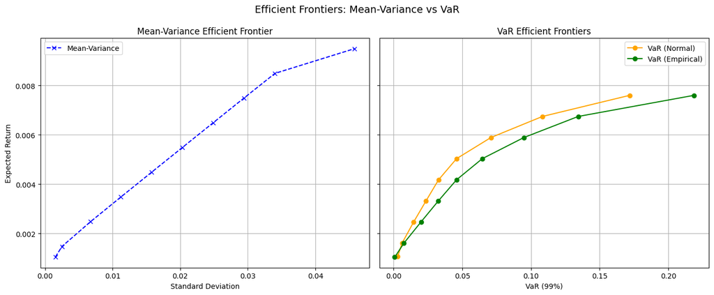

```python
# MEAN VARIANCE OPTIMIZATION
def optimize_mv(cov, mu, target_return):
    risks, rets, weights = [], [], []
    m = len(mu)

    for tr in target_return:
        w = cp.Variable(m)
        constraints = [
            cp.sum(w) == 1,
            w >= 0,
            mu @ w >= tr
        ]
        obj = cp.Minimize(cp.quad_form(w, cov))
        prob = cp.Problem(obj, constraints)
        prob.solve()

        # Store results
        risks.append(np.sqrt(prob.value))      # portfolio std dev (risk)
        weights.append(w.value)                # optimal weights

    return risks, weights

# generate 10 equally spaced return targets between: The lowest expected return (mu_series.min()), and
# The highest expected return (mu_series.max()).
targets = np.linspace(mu.min(), mu.max(), 10)

# get risk return for each target
risk_mv, w_mv = optimize_mv(sigma, mu.values, targets)
ret_mv = [w @ mu for w in w_mv]




# Create two side-by-side plots
fig, axes = plt.subplots(1, 2, figsize=(14, 6), sharey=True)

# --- Left: Mean-Variance Frontier ---
axes[0].plot(risk_mv, ret_mv, '--x', label='Mean-Variance', color='blue')
axes[0].set_title('Mean-Variance Efficient Frontier')
axes[0].set_xlabel('Standard Deviation')
axes[0].set_ylabel('Expected Return')
axes[0].legend()
axes[0].grid(True)

# --- Right: CVaR Frontiers ---
axes[1].plot(cvar_norm, ret_norm, '-o', label='VaR (Normal)', color='orange')
axes[1].plot(cvar_emp, ret_emp, '-o', label='VaR (Empirical)', color='green')
axes[1].set_title('VaR Efficient Frontiers')
axes[1].set_xlabel('VaR (99%)')
axes[1].legend()
axes[1].grid(True)

# Tidy layout
plt.suptitle('Efficient Frontiers: Mean-Variance vs VaR', fontsize=14)
plt.tight_layout(rect=[0, 0.03, 1, 0.99])
plt.show()
```

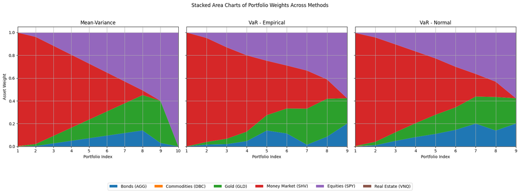

```python
# Weights Plots for each method
# Convert to matrices
# handle potential NaN values from failed optimizations by filtering them out
weights_mv = np.array([w for w in w_mv if w is not None and not np.isnan(w).any()])
weights_emp = np.array([w for w in w_emp if w is not None and not np.isnan(w).any()])
weights_norm = np.array([w for w in w_norm if w is not None and not np.isnan(w).any()])

# Prepare plotting
fig, axes = plt.subplots(1, 3, figsize=(18, 6), sharey=True)

weight_sets = [
    (weights_mv, 'Mean-Variance'),
    (weights_emp, 'VaR - Empirical'),
    (weights_norm, 'VaR - Normal')
]
colors = plt.cm.tab10.colors  # 10 distinguishable colors
asset_labels = returns.columns

for i, (weights_matrix, title) in enumerate(weight_sets):
    ax = axes[i]
    if weights_matrix.size > 0:
        num_portfolios = len(weights_matrix)
        portfolio_indices = range(1, num_portfolios + 1)
        ax.stackplot(portfolio_indices, weights_matrix.T, labels=asset_labels, colors=colors[:weights_matrix.shape[1]])
        ax.set_xlim(1, num_portfolios) # Dynamically set x-axis limit
    ax.set_title(title)
    ax.set_xlabel("Portfolio Index")
    ax.grid(True)


axes[0].set_ylabel("Asset Weight")
handles, labels = axes[0].get_legend_handles_labels()
fig.legend(handles, labels, loc='upper center', bbox_to_anchor=(0.5, 0), ncol=len(asset_labels))
plt.suptitle("Stacked Area Charts of Portfolio Weights Across Methods", y=1.02)
plt.tight_layout(rect=[0, 0.1, 1, 1]) # Adjust layout to make space for legend
plt.show()
```

The **efficient frontiers** highlight the trade-off between risk and return in the various optimisation strategies. Moving on to VaR-constrained optimisation, we see how the introduction of downside risk constraints modifies the frontier compared to the MV frontier, emphasising protection against the most severe losses.

The contrast between frontiers estimated based on normality assumptions and those generated using empirical bootstrapping highlights estimation risk. The bootstrap frontier, although slightly less smooth, captures historical anomalies and is more representative of tail behaviour, providing a more conservative assessment of risk-return trade-offs.

The **weight chart**, on the other hand, offers further insight into how the optimiser reacts to these constraints. Within the VaR-constrained paradigm, portfolios show a strong preference for gold (GLD) and the money market (SHV), especially in conservative allocations, because these assets minimise exposure to market tail movements. As we increase the target return, weights migrate toward equities (SPY) to increase growth, while bonds continue to be underrepresented because they contribute minimally to risk-adjusted returns. The omission of real estate (VNQ) and commodities (DBC) indicates that these asset classes provide minimal incremental diversification in the context of the CVaR constraint.

This analysis confirms the choice of a top-segment portfolio on the constrained VaR frontier for the client, which balanced growth opportunities with strong downside protection.

### Optimal portfolio analysis and interpretation of optimal allocation

The Value at Risk (VaR) and Conditional Value at Risk (CVaR) graph identifies potential losses for the portfolio in the event of extreme market scenarios. VaR establishes the maximum expected loss with a 99% confidence level over a one-month period, whereas CVaR quantifies the average loss exceeding this point, which offers a more complete indication of tail risk. Both measures underscore the necessity for including downside risk constraints in portfolio optimization. To better understand the concept of VaR and CVaR, we show the distribution of historical returns and highlight them on the **optimal portfolio**, the one with the highest Sharp Ratio.

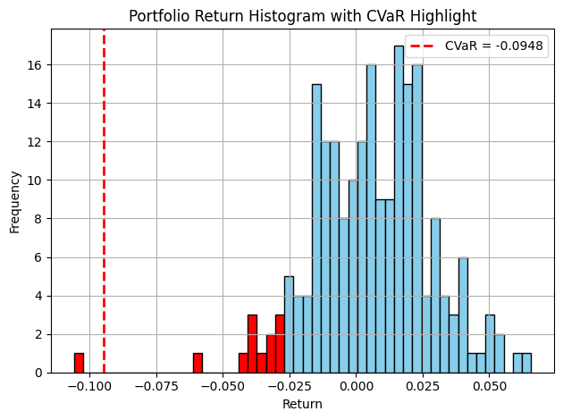

```python
## plotting the CVaR histogram
def plot_cvar_histogram(returns, var, cvar, bins=50):
    counts, bin_edges, patches = plt.hist(returns, bins=bins, edgecolor='black')

    # Color bars: red if bin is below VaR (losses), blue otherwise
    for i in range(len(patches)):
        if bin_edges[i] < var:
            patches[i].set_facecolor('red')
        else:
            patches[i].set_facecolor('skyblue')

    # CVaR line
    plt.axvline(cvar, color='red', linestyle='--', linewidth=2, label=f'CVaR = {cvar:.4f}')

    # Titles and labels
    plt.title('Portfolio Return Histogram with CVaR Highlight')
    plt.xlabel('Return')
    plt.ylabel('Frequency')
    plt.grid(True)
    plt.legend()
    plt.tight_layout()
    plt.show()


# set portfolio of interest
ptf_n = 6

# plot
plot_cvar_histogram(w_emp[ptf_n] @ returns.values.T, var=-theta_emp[ptf_n], cvar=-cvar_emp[ptf_n])



# #Optimal Expected Return
optimal_return_CVaR = ret_emp[ptf_n]
# print(f"Optimal Expected Return: {optimal_return_CVaR:.4f}")

# # Optimal Standard Deviation
optimal_std_dev_CVaR = np.sqrt(w_emp[ptf_n] @ sigma @ w_emp[ptf_n])
# print(f"Optimal Standard Deviation: {optimal_std_dev_CVaR:.4f}")

# # Optimal VaR
optimal_var_CVaR = -theta_emp[ptf_n]
# print(f"Optimal VaR: {optimal_var:.4f}")

# # OPTIMAL CVaR
optimal_cvar_CVaR = -cvar_emp[ptf_n]
# print(f"Optimal CVaR: {optimal_cvar:.4f}")

# # Optimal VaR-Constrained portfolio weights
optimal_weights_CVaR = w_emp[ptf_n]
# print("\nOptimal VaR-Constrained Portfolio Weights:")
# for ticker, weight in zip(returns.columns, optimal_weights):
#     print(f"{ticker}: {weight:.4f}")
# store optimal weights in a DF
optimal_weights_CVaR = pd.DataFrame(optimal_weights_CVaR.round(4), index=returns.columns, columns=["Weight"])
# Convert to a Series for easier access

cvar_returns = returns @ optimal_weights_CVaR["Weight"]

optimal_weights_CVaR = optimal_weights_CVaR["Weight"]
# print(optimal_weights_CVaR)
```

The optimisation identifies an **optimal portfolio with VaR constraint** that balances return potential with downside risk protection. We note that the returns of this portfolio have a significant CVaR, due to a large left tail in the distribution.

In particular the Optimal VaR-Constrained Portfolio is characterized by:

- Optimal Expected Return: 0.59%
- Optimal Standard Deviation: 2.26%
- Optimal VaR: 3.00%
- Optimal CVaR: 9.48%

Optimal VaR-Constrained Portfolio Weights:

| Asset | Weight |
| --- | --- |
| Bonds (AGG) | 0.00% |
| Commodities (DBC) | 0.00% |
| Gold (GLD) | 31.67% |
| Money Market (SHV) | 33.50% |
| Equities (SPY) | 33.43% |
| Real Estate (VNQ) | 0.00% |

This optimal portfolio includes a decrease in expected return and a significant increase in CVaR, but the portfolio's standard deviation is more than 1% lower than the MV optimisation. Compared to the MV optimisation, the allocation to the money market is much smaller, while gold and equities gain greater weight. The portfolio takes on an almost equally weighted form between the three ETFs mentioned.

**Interpretation of portfolio allocation with VaR constraint**

Optimisation with VaR constraint assigns significant weight to gold (GLD). This is due to the historical function of this asset as a hedge in periods of market stress and its low correlation with equities (SPY). In cases of extreme downturns, gold has tended to preserve capital or even increase in value, making it extremely desirable in a risk-reduction context. This large allocation is also due to the fact that the model is based solely on historical data and may overestimate the past behaviour of gold in times of crisis.

CVaR figures around 10% seem high because they represent the average losses in the worst 1% of monthly results. Although such levels are not unusual for portfolios with significant exposure to equities, they can be reduced by lowering target returns, adding more bonds and cash, or extending the optimisation horizon to more than one month.

In summary, the VaR-constrained optimised portfolio reveals some fundamental limitations of the approach. Although the model may impose a strict monthly VaR limit of 3% at 99%, the resulting portfolio has a very high conditional value at risk (CVaR) of 9.48% and a reduction in expected return to 0.59% per month, which could severely penalise the portfolio's long-term performance.

From a **long-term asset management perspective**, this portfolio is suboptimal in terms of both risk-adjusted performance and diversification. In fact, assets such as bonds are neglected and the high weighting given to gold could be dangerous.

As an alternative to the VaR constraint, the explicit minimisation of CVaR should provide a better framework for controlling downside risk, as CVaR explicitly addresses losses at the tail of the return distribution. However, this is not the case. In fact, the minimisation of CVaR, the results of which we do not disclose here, leads to a further sacrifice of expected returns and increases the concentration in assets that are not sustainable for long-term growth.

These results indicate the need to align the optimisation objective with the client's actual risk tolerance. In practice, an intermediate portfolio that balances growth opportunities with tail risk management will be a more suitable choice for long-term wealth accumulation and preservation.

## 05. Estimation Risk Discussion and Model Improvement

One of the key challenges in portfolio optimization is **estimation risk** due to the uncertainty and possible inaccuracy of inputs to the model, mainly expected returns, volatilities, and correlations. Mean-variance and CVaR-constrained models put a lot of emphasis on historical data for estimating the parameters. But these estimates are noisy by nature and are susceptible to sampling variation, particularly if one takes a relatively short time horizon or if the asset return distributions have skewness and excess kurtosis.

In the current study, the VaR-optimizer's propensity for putting extreme weights, e.g., the overweighting of Gold (GLD), can be partly ascribed to estimation risk. Minor perturbations in estimated expected returns or covariances may cause the portfolio composition to change radically, as the optimizer attempts to take advantage of small perceived performance edges in the historical record. Likewise, the disparity between the frontiers arrived at under parametric (normality) assumptions and those produced by bootstrapping is indicative of the impact of estimation error and the existence of historical anomalies in the data.

To reduce estimation risk, the following improvements could be made:

- Resampling techniques to adjust for uncertainty in parameter estimates and generate more efficient frontiers that are robust.
- The Black-Litterman model, which blends equilibrium market returns and investors' views, can also moderate the sensitivity of portfolio weights to estimation error. This method produces allocations that are not just theoretically optimal but also more stable and in accord with practical investment concerns.
- Introducing Weight Constraints and Regularization, to prevent over-concentration in one specific asset (as with Gold in CVaR-restricted portfolios), weight constraints can be set in explicit terms or L2 regularization (ridge penalty) can be applied. This encourages diversification by penalizing large weight values.

It is important to address estimation risk so that portfolio recommendations are strong across various market regimes and do not depend too much on historical trends that might not continue going forward.

```python
# Ridge Optimization: MV e VaR-constrained portfolios

import yfinance as yf
import pandas as pd
import numpy as np
from sklearn.linear_model import RidgeCV, Ridge
from sklearn.covariance import LedoitWolf
import matplotlib.pyplot as plt
import cvxpy as cp
from scipy.optimize import minimize

# =============================
# Step 1. Cross-validation for Ridge penalization terms
# =============================

tickers = ["SPY", "AGG", "DBC", "GLD", "VNQ", "SHV"]
data = yf.download(tickers, start="2007-12-01", end="2025-06-30", auto_adjust=True, progress=False)["Close"]

# Monthly prices and returns
monthly_prices = data.resample('ME').last()
returns_monthly = monthly_prices.pct_change().dropna()

# Feature engineering: momentum, volatility, last return
features_all = pd.DataFrame(index=returns_monthly.index)
window_short = 2
window_long = 6

for ticker in tickers:
    ret = returns_monthly[ticker]
    features_all[f"{ticker}_Return_MA{window_short}"] = ret.rolling(window=window_short).mean()
    features_all[f"{ticker}_Return_MA{window_long}"] = ret.rolling(window=window_long).mean()
    features_all[f"{ticker}_Volatility_MA{window_short}"] = ret.rolling(window=window_short).std()
    features_all[f"{ticker}_Volatility_MA{window_long}"] = ret.rolling(window=window_long).std()
    features_all[f"{ticker}_Last_Return"] = ret

# Target: next month's return
targets_all = returns_monthly.shift(-1).dropna()

# Align indices
common_index = features_all.index.intersection(targets_all.index)
features_all = features_all.loc[common_index].dropna()
targets_all = targets_all.loc[common_index].dropna()

# Train/Test split
split_index = int(len(features_all) * 0.8)
X_train, X_test = features_all.iloc[:split_index], features_all.iloc[split_index:]
y_train, y_test = targets_all.iloc[:split_index], targets_all.iloc[split_index:]

# =============================
# Step 2. Ridge Regression
# =============================

alphas = np.logspace(-3, 3, 100)
ridge_expected_returns_monthly = pd.Series(index=tickers)
ridge_coefs = {}

for ticker in tickers:
    feature_cols = [col for col in X_train.columns if col.startswith(ticker)]
    X_train_t = X_train[feature_cols]

    ridge_cv = RidgeCV(alphas=alphas, cv=10, scoring='neg_mean_squared_error')
    ridge_cv.fit(X_train_t, y_train[ticker])
    ridge_model = Ridge(alpha=ridge_cv.alpha_)
    ridge_model.fit(X_train_t, y_train[ticker])

    preds_train = ridge_model.predict(X_train_t)
    ridge_expected_returns_monthly[ticker] = preds_train.mean()
    ridge_coefs[ticker] = ridge_model.coef_

# Display Ridge vs Historical returns
ridge_table = pd.DataFrame({
    "Historical Return": returns_monthly.mean(),
    "Ridge Expected Return": ridge_expected_returns_monthly,
    "Difference": ridge_expected_returns_monthly - returns_monthly.mean()
})
# print("\n📊 Ridge vs Historical Returns:")
# print(ridge_table.round(6))

# =============================
# Step 3. Mean-Variance Optimization (Ridge)
# =============================

lw = LedoitWolf()
cov_matrix = lw.fit(returns_monthly).covariance_
rf = returns_monthly["SHV"].mean()
idx_shv = tickers.index("SHV")
idx_agg = tickers.index("AGG")

def neg_sharpe_ratio(w, expected_returns, cov_matrix, rf):
    port_return = np.dot(w, expected_returns)
    port_volatility = np.sqrt(np.dot(w.T, np.dot(cov_matrix, w)))
    return -(port_return - rf) / port_volatility

constraints_mv = [
    {"type": "eq", "fun": lambda w: np.sum(w) - 1},
    {"type": "ineq", "fun": lambda w: w},  # w >= 0
    {"type": "ineq", "fun": lambda w: w[idx_agg] + w[idx_shv] - 0.20}
]

x0 = np.ones(len(tickers)) / len(tickers)

result_mv = minimize(
    neg_sharpe_ratio, x0,
    args=(ridge_expected_returns_monthly.values, cov_matrix, rf),
    constraints=constraints_mv,
    method="SLSQP"
)

weights_mv_ridge = result_mv.x
port_returns_mv = returns_monthly @ weights_mv_ridge
ER_mv = np.dot(weights_mv_ridge, ridge_expected_returns_monthly.values)
SD_mv = np.sqrt(weights_mv_ridge @ cov_matrix @ weights_mv_ridge)
VaR_mv = abs(np.percentile(port_returns_mv, 1))
CVaR_mv = abs(port_returns_mv[port_returns_mv <= -VaR_mv].mean())

# print("\n--- 📈 Mean-Variance Ridge Optimization ---")
# print(f"Expected Return (monthly): {ER_mv:.4%}")
# print(f"Portfolio Volatility: {SD_mv:.4%}")
# print(f"1% VaR (monthly): {VaR_mv:.4%}")
# print(f"1% CVaR (monthly): {CVaR_mv:.4%}")
# for t, wgt in zip(tickers, weights_mv_ridge):
#     print(f"{t}: {wgt:.2%}")

# =============================
# Step 4. VaR-Constrained Optimization (Ridge)
# =============================

def optimize_var_constrained(scenarios, mu, alpha, var_limit):
    """
    Maximizes expected return subject to VaR constraint
    """
    n, m = scenarios.shape
    w = cp.Variable(m)
    portfolio_return = mu @ w

    losses = -scenarios.values @ w
    theta = cp.Variable()
    z = cp.Variable(n)

    constraints = [
        cp.sum(w) == 1,
        w >= 0,
        cp.sum(cp.vstack([w[idx_agg], w[idx_shv]])) >= 0.20,
        z >= losses - theta,
        z >= 0,
        theta <= var_limit
    ]

    objective = cp.Maximize(portfolio_return)
    prob = cp.Problem(objective, constraints)
    prob.solve(solver=cp.SCS, verbose=False)

    return w.value, theta.value

n_runs = 5
weights_list = []
var_list = []

for _ in range(n_runs):
    scenarios = returns_monthly.sample(n=5000, replace=True)
    w, var = optimize_var_constrained(scenarios, ridge_expected_returns_monthly.values, 0.99, 0.03)
    weights_list.append(w)
    var_list.append(var)

weights_var_ridge = np.mean(weights_list, axis=0)
VaR_var_ridge = np.mean(var_list)
port_returns_var_ridge = returns_monthly @ weights_var_ridge
CVaR_var_ridge = abs(port_returns_var_ridge[port_returns_var_ridge <= -VaR_var_ridge].mean())
SD_var_ridge = np.sqrt(weights_var_ridge @ cov_matrix @ weights_var_ridge)

# print("\n--- 📉 VaR-Constrained Ridge Optimization ---")
# print(f"Expected Return (monthly): {np.dot(weights_var_ridge, ridge_expected_returns_monthly.values):.4%}")
# print(f"Portfolio Volatility: {SD_var_ridge:.4%}")
# print(f"1% VaR (monthly): {VaR_var_ridge:.4%}")
# print(f"1% CVaR (monthly): {CVaR_var_ridge:.4%}")
# for t, wgt in zip(tickers, weights_var_ridge):
#     print(f"{t}: {wgt:.2%}")


# ============================
# Step 5. Fai una tabella con righe: ER, SD, VaR e CVaR e pesi dei titoli e nelle colonne voglio MV opt, CVaR opt, MV-ridge opt, CVaR-Ridge opt (per le prime due colonne i dati sono già calcolati nel mio codice: optimal_weights_MV, max_return_M
# V, max_return_std_dev_MV, optimal_var_MV, optimal_cvar_MV  per il portafoglio MV e poi per quello CVaR constrained: optimal_return_CVaR, optimal_std_dev_CVaR, optimal_var_CVaR, optimal_cvar_CVaR, optimal_weights_CVaR.
# ============================
# summary_table = pd.DataFrame(index=["Expected Return", "Volatility", "VaR(99%)", "CVaR(99%)"] + tickers)
# # Function to compute stats
# def compute_stats(weights, returns):
#     port_returns = returns @ weights
#     er = port_returns.mean()
#     sd = port_returns.std()
#     var = abs(np.percentile(port_returns, 1))
#     cvar = abs(port_returns[port_returns <= -var].mean())
#     return er, sd, var, cvar, weights
# # Fill table
# for name, weights, returns in [
#     ("MV-Hist", optimal_weights_MV, returns_monthly),
#     ("CVaR-Hist", optimal_weights_CVaR, returns_monthly),
#     ("MV-Ridge", weights_mv_ridge, returns_monthly),
#     ("CVaR-Ridge", weights_cvar_ridge, returns_monthly)
# ]:
#     er, sd, var, cvar, w = compute_stats(weights, returns)
#     summary_table[name] = [er, sd, var, cvar] + list(weights)
# print("\n📊 Portfolio Comparison (Monthly):")
# print(summary_table.applymap(lambda x: f"{x:.4%}" if isinstance(x, float) else x))

# ============================
# Step 6. Con i pesi dei 4 portafogli e i ritorni storici (usati per tutti e 4 i portafogli) fai i ritorni cumulati e simula l'andamento di un portafoglio che parte con 100M.
# ============================
# initial_capital = 100_000_000
# portfolios = {
#     "MV-Hist": optimal_weights_MV,
#     "CVaR-Hist": optimal_weights_CVaR,
#     "MV-Ridge": weights_mv_ridge,
#     "CVaR-Ridge": weights_cvar_ridge
# }
# portfolio_values = pd.DataFrame(index=returns_monthly.index)
# for name, weights in portfolios.items():
#     cumulative = (1 + returns_monthly @ weights).cumprod()
#     portfolio_values[name] = initial_capital * cumulative
# # Plot portfolio growth
# plt.figure(figsize=(12, 6))
# portfolio_values.plot(ax=plt.gca())
# plt.title("Portfolio Growth (Initial $100M)")
# plt.ylabel("Portfolio Value ($)")
# plt.xlabel("Date")
# plt.grid(True)
# plt.tight_layout()
# plt.show()
```

### Incorporating Weight Constraints - Ridge Regression

To reduce estimation risk and to improve long-term portfolio weight stability, we added Ridge regression (L2 penalty) to the optimization. Ridge modifies return estimation by penalizing large coefficients in the regression formula, smoothing effectively the noise in the historical data and preventing extreme portfolio weights. This approach has several advantages: it distributes capital more evenly across a range of assets, does not over-adapt to past market idiosyncrasies, and creates portfolios that are less sensitive to changing market conditions. Ridge differs from Black-Litterman in that it applies only data-based regularization, without relying on subjective market expectations, which are often difficult to quantify and verify.

To improve the optimization model then the penalty term was introduced by calculating it through Cross Validation for each individual ETF. With these penalty terms the adjusted expected returns, called Ridge expected returns, were then calculated:

Ridge vs Historical Returns in percentages:

| Ticker | Historical Return (%) | Ridge Expected Return (%) | Difference (%) |
| --- | --- | --- | --- |
| AGG | 0.2379 | 0.3166 | 0.0787 |
| DBC | 0.0476 | -0.1276 | -0.1751 |
| GLD | 0.7371 | 0.5085 | -0.2286 |
| SHV | 0.1043 | 0.0513 | -0.0530 |
| SPY | 0.9495 | 1.0025 | 0.0531 |
| VNQ | 0.7419 | 0.9421 | 0.2003 |

Using the penalty-adjusted returns we can then redo MV and VaR-constrained optimization obtaining seemingly much more balanced and realistically usable results:

- The **Mean-Variance Ridge optimization** had an optimal portfolio with these characteristics:
  - Expected Monthly Return: 0.7879%
  - Portfolio Volatility: 1.5404%
  - Value-at-Risk (99%): 3.6869%
  - Conditional VaR (99%): 4.7546%
  - Optimal Weights: 64.32% Equities (SPY), 20.00% Bonds (AGG), 15.68% Gold (GLD).

### Comparative Insights & Considerations

The two Ridge-based optimization methods represent different trade-offs:

- The Mean-Variance Ridge portfolio prioritizes diversified exposure with significant weightings to defensive assets (Gold and Bonds) to deliver smoother performance over market cycles. Although its VaR is marginally higher than the target, it provides an excellent trade-off between risk and return.
- The VaR-Constrained Ridge portfolio, on the contrary, is more concentrated in Equities. Although the rigid VaR limit guarantees protection against tail losses at the given confidence level, it can generate overconfidence during periods of low volatility, possibly leaving the client exposed to unexpected tail risks not covered by VaR alone.

**Note:** The Ridge-optimal portfolios exhibit high expected returns with very low ex-ante risk measures (volatility, VaR, and CVaR). This is the direct result of Ridge regularization, which shrinks extreme return and covariance estimates towards their means. Consequently, risky assets like equities might seem more stable within the Ridge estimation framework, and the optimizer can allocate more weight to them without incurring large risk metrics. However, these numbers are forward-looking and represent the smoothed expectations of the model, not realized historical performance. When applied to historical data (ex-post), Ridge portfolios have a tendency to exhibit lower returns and higher risk than implied by the ex-ante estimates, since regularization prefers stability and robustness to fitting extreme market moves.

Therefore, let us examine these new portfolios and compare them to the previous ones to understand which is the best choice for the client's long-term strategy.

## 06. Comparative Analysis of Portfolio Strategies and Recommendation for the Client

Let us look at a comparison of the 4 optimal portfolios obtained from the four different optimizations:

| / | MV-Historical | VaR-Historical | MV-Ridge | VaR-Ridge |
| --- | --- | --- | --- | --- |
| **Metrics (Ex-Ante):** | / | / | / | / |
| **Expected Return** | 0.81% | 0.59% | 0.79% | 0.87% |
| **Volatility** | 3.74% | 2.26% | 1.54% | 1.73% |
| **VaR (99%)** | 1.43% | 3.00% | 3.69% | 0.10% |
| **CVaR (99%)** | 2.05% | 9.48% | 4.75% | 1.34% |
| **Weights:** | / | / | / | / |
| **SPY** (Equities) | 12.40% | 33.43% | 64.32% | 80.00% |
| **AGG** (Bonds) | 2.86% | 0.00% | 20.00% | 20.00% |
| **GLD** (Gold) | 7.01% | 31.67% | 15.68% | 0.00% |
| **SHV** (Money Market) | 77.72% | 33.50% | 0.00% | 0.00% |
| **DBC / VNQ** (Others) | 0.00% | 0.00% | 0.00% | 0.00% |

The summary table highlights the main trade-offs between return, volatility, and downside risk in the four optimization methods.

- The **MV-Historical portfolio** offers a very high expected return (0.81%), but makes extensive use of cash (SHV) and equities (SPY), resulting in moderate volatility (3.74%) and relatively low tail risk (CVaR 2.05%). However, this allocation may overlook the potential diversification benefits offered by other asset classes that would be necessary for long-term growth.
- The **VaR-Historical portfolio** achieves a significant reduction in volatility (2.26%), but at the cost of a significantly lower expected return (0.59%). Its CVaR rises sharply to 9.48%, indicating that, although the 3% Value-at-Risk constraint (99% confidence) is met, the portfolio remains vulnerable to extreme losses beyond this threshold. This therefore appears to be a suboptimal solution and is unlikely to be acceptable to the client, as it is too focused on highly volatile assets such as gold.
- The **MV-Ridge portfolio**, by regularizing return and covariance estimates, avoids extreme allocations and achieves a more balanced exposure (64% SPY, 20% AGG, 15% GLD). The ex-ante expected return (0.79%) is slightly lower than its historical counterpart, but the portfolio has more uniform risk characteristics (SD 1.54%, CVaR 4.75%) thanks to the Ridge penalty, which reduces the risk of overfitting and estimation risk.
- The **VaR-Ridge portfolio** is concentrated on only two assets: 20% bonds and 80% equities. Although it has the highest ex-ante expected return of all the portfolios (0.87%), it seems too concentrated on equities. From a downside risk perspective, it also appears to be an excellent portfolio, but we should remember what we said above: ex-post, the expected return of the portfolio is lower than that shown ex-ante, and the risk measures are also higher.

These considered are the optimal portfolios generated by the optimizations; however, depending on the client's choice and the utility the portfolio can provide him, other portfolios along the **efficient frontier** can also be chosen. We then look at the graphs of the efficient frontiers for the different optimizations.

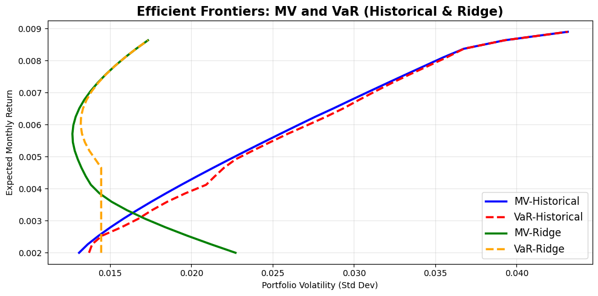

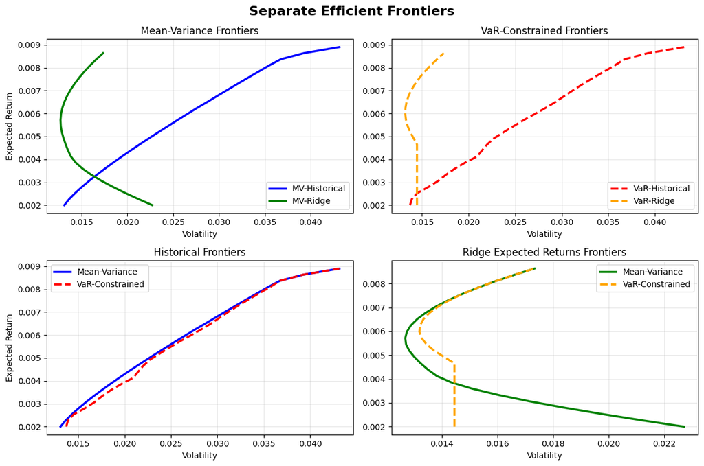

```python
import yfinance as yf
import pandas as pd
import numpy as np
from sklearn.covariance import LedoitWolf
import matplotlib.pyplot as plt
from scipy.optimize import minimize
import cvxpy as cp

# =============================
# STEP 1: Data Preparation
# =============================
tickers = ["SPY", "AGG", "DBC", "GLD", "VNQ", "SHV"]
data = yf.download(tickers, start="2007-12-01", end="2025-06-30", auto_adjust=True, progress=False)["Close"]
monthly_prices = data.resample('ME').last()
returns_monthly = monthly_prices.pct_change().dropna()

# Covariance matrix
lw = LedoitWolf()
cov_matrix = lw.fit(returns_monthly).covariance_
rf = returns_monthly["SHV"].mean()
idx_shv = tickers.index("SHV")
idx_agg = tickers.index("AGG")

# Historical mean returns
historical_returns = returns_monthly.mean()

# Ridge expected returns (pd.Series)
ridge_expected_returns_monthly = pd.Series({
    "SPY": 0.010025,
    "AGG": 0.003166,
    "DBC": -0.001276,
    "GLD": 0.005085,
    "VNQ": 0.009421,
    "SHV": 0.000513
})

# =============================
# STEP 2: Functions for Frontiers
# =============================

# Mean-Variance Frontier
def compute_mv_frontier(expected_returns, cov_matrix):
    risks, returns_, weights_ = [], [], []
    for target_return in np.linspace(0.002, 0.015, 50):
        constraints = [
            {"type": "eq", "fun": lambda w: np.sum(w) - 1},
            {"type": "ineq", "fun": lambda w: w},  # no short-selling
            {"type": "eq", "fun": lambda w: np.dot(w, expected_returns) - target_return},
            {"type": "ineq", "fun": lambda w: w[idx_agg] + w[idx_shv] - 0.20}  # Bonds + Cash >= 20%
        ]
        x0 = np.ones(len(tickers)) / len(tickers)
        result = minimize(lambda w: np.sqrt(w.T @ cov_matrix @ w), x0,
                          constraints=constraints, method="SLSQP")
        if result.success:
            port_volatility = np.sqrt(result.x.T @ cov_matrix @ result.x)
            risks.append(port_volatility)
            returns_.append(target_return)
            weights_.append(result.x)
    return np.array(risks), np.array(returns_), np.array(weights_)

# VaR-Constrained Frontier
def compute_var_constrained_frontier(expected_returns, var_limit, alpha=0.99):
    risks, returns_, weights_ = [], [], []
    for target_return in np.linspace(0.002, 0.015, 50):
        w = cp.Variable(len(tickers))
        z = cp.Variable(returns_monthly.shape[0])
        theta = cp.Variable()

        loss = -returns_monthly.values @ w

        constraints = [
            cp.sum(w) == 1,
            w >= 0,
            cp.sum(cp.vstack([w[idx_agg], w[idx_shv]])) >= 0.20,
            expected_returns.values @ w >= target_return,
            z >= loss - theta,
            z >= 0,
            theta <= var_limit
        ]

        objective = cp.Minimize(theta + cp.sum(z) / (returns_monthly.shape[0] * (1 - alpha)))
        prob = cp.Problem(objective, constraints)

        try:
            prob.solve(solver=cp.SCS, verbose=False)
            if w.value is not None:
                port_volatility = np.sqrt(w.value.T @ cov_matrix @ w.value)
                risks.append(port_volatility)
                returns_.append(target_return)
                weights_.append(w.value)
        except:
            continue
    return np.array(risks), np.array(returns_), np.array(weights_)

# =============================
# STEP 3: Compute Frontiers
# =============================

# Historical frontiers
mv_risks_hist, mv_returns_hist, mv_weights_hist = compute_mv_frontier(historical_returns.values, cov_matrix)
var_risks_hist, var_returns_hist, var_weights_hist = compute_var_constrained_frontier(historical_returns, var_limit=0.03)

# Ridge frontiers
mv_risks_ridge, mv_returns_ridge, mv_weights_ridge = compute_mv_frontier(ridge_expected_returns_monthly.values, cov_matrix)
var_risks_ridge, var_returns_ridge, var_weights_ridge = compute_var_constrained_frontier(ridge_expected_returns_monthly, var_limit=0.03)

# =============================
# STEP 4: Plot Combined Frontiers (All in One)
# =============================

plt.figure(figsize=(10, 5))
plt.plot(mv_risks_hist, mv_returns_hist, 'b-', linewidth=2.5, label="MV-Historical")
plt.plot(var_risks_hist, var_returns_hist, 'r--', linewidth=2.5, label="VaR-Historical")
plt.plot(mv_risks_ridge, mv_returns_ridge, 'g-', linewidth=2.5, label="MV-Ridge")
plt.plot(var_risks_ridge, var_returns_ridge, 'orange', linestyle='--', linewidth=2.5, label="VaR-Ridge")
plt.title("Efficient Frontiers: MV and VaR (Historical & Ridge)", fontsize=15, fontweight='bold')
plt.xlabel("Portfolio Volatility (Std Dev)")
plt.ylabel("Expected Monthly Return")
plt.grid(True, alpha=0.3)
plt.legend(fontsize=12)
plt.tight_layout()
plt.show()

# =============================
# STEP 5: Plot Separate Frontiers
# =============================

fig, axes = plt.subplots(2, 2, figsize=(12, 8))

# Top left: MV Historical & Ridge
axes[0,0].plot(mv_risks_hist, mv_returns_hist, 'b-', linewidth=2.5, label="MV-Historical")
axes[0,0].plot(mv_risks_ridge, mv_returns_ridge, 'g-', linewidth=2.5, label="MV-Ridge")
axes[0,0].set_title("Mean-Variance Frontiers")
axes[0,0].set_xlabel("Volatility")
axes[0,0].set_ylabel("Expected Return")
axes[0,0].legend()
axes[0,0].grid(True, alpha=0.3)

# Top right: VaR-Constrained Historical & Ridge
axes[0,1].plot(var_risks_hist, var_returns_hist, 'r--', linewidth=2.5, label="VaR-Historical")
axes[0,1].plot(var_risks_ridge, var_returns_ridge, 'orange', linestyle='--', linewidth=2.5, label="VaR-Ridge")
axes[0,1].set_title("VaR-Constrained Frontiers")
axes[0,1].set_xlabel("Volatility")
axes[0,1].legend()
axes[0,1].grid(True, alpha=0.3)

# Bottom left: Historical Frontiers
axes[1,0].plot(mv_risks_hist, mv_returns_hist, 'b-', linewidth=2.5, label="Mean-Variance")
axes[1,0].plot(var_risks_hist, var_returns_hist, 'r--', linewidth=2.5, label="VaR-Constrained")
axes[1,0].set_title("Historical Frontiers")
axes[1,0].set_xlabel("Volatility")
axes[1,0].set_ylabel("Expected Return")
axes[1,0].legend()
axes[1,0].grid(True, alpha=0.3)

# Bottom right: Ridge Frontiers
axes[1,1].plot(mv_risks_ridge, mv_returns_ridge, 'g-', linewidth=2.5, label="Mean-Variance")
axes[1,1].plot(var_risks_ridge, var_returns_ridge, 'orange', linestyle='--', linewidth=2.5, label="VaR-Constrained")
axes[1,1].set_title("Ridge Expected Returns Frontiers")
axes[1,1].set_xlabel("Volatility")
axes[1,1].legend()
axes[1,1].grid(True, alpha=0.3)

plt.suptitle("Separate Efficient Frontiers", fontsize=16, fontweight='bold')
plt.tight_layout()
plt.show()
```

The contrast between the four efficient frontiers provides an in-depth view of how each optimization technique balances risk and return.

Although both the historical frontiers and those corrected for Ridge Mean-Variance show the classic trade-off—an increase in risk leads to an increase in potential returns—the Ridge frontiers are slightly further to the left, indicating more diversified and stable allocations, a direct consequence of regularization that mitigates extreme weights.

Comparing the two optimization methodologies, the VaR-constrained frontiers are narrower and shifted further to the right, showing how the strict imposition of a Value-at-Risk constraint tightly circumscribes the set of available portfolios, as noted earlier. This constraint favors downside protection but reduces the potential for high returns. As might be expected, the Ridge-based VaR frontier is even more conservative than its historical equivalent, highlighting how the Ridge penalty rewards stability over adventurous positioning.

### Final considerations and recommendations for the client

For the long-term asset management plan, the Mean-Variance Ridge solution seems more appropriate as it incorporates greater diversification and stability without having to rely on historical distribution assumptions on which VaR-constrained optimization must necessarily be based. However, the final choice of portfolio should take into account the client's risk tolerance and liquidity requirements, balancing capital appreciation with acceptable drawdown levels.

Both Ridge models generated more realistic and potentially feasible portfolio solutions in practice. By penalizing extreme allocations, Ridge regularization allocates capital more evenly across assets, avoiding high concentration in assets such as gold that do not typically account for a large portion of the portfolio allocation. This results in portfolios that are more in line with long-term asset management principles and less subject to distortions due to anomalies in historical data.

For the client, these observations underscore that while the mean-variance strategy offers higher potential returns, this comes at the cost of greater exposure to volatility and tail risks. Conversely, models with VaR constraints effectively limit downside risk but impose more severe constraints on achievable performance.

A conservative approach to portfolio construction would be to choose a portfolio along the Ridge Mean-Variance frontier that balances growth potential with stability, in line with the client's risk tolerance. However, since portfolio construction is personal, it is necessary to combine the client's wishes and risk appetite in deciding on the allocation that best suits their long-term financial goals.